# India Travelers

Jacob Palenchar

9 April 2022

# Load Packages

```r
require(dada2)
require(dplyr)
require(ggplot2)
require(phyloseq)
require(knitr)
require(kableExtra)
require(microbiome)
require(vegan)
require(ape)
require(betapart)
```

# India Travelers

Travelling to India can be hazardous

There is a prevalence of antibiotic resistant bacteria in India and the intestines of travelers to India are often colonized with new bacteria. Extended-spectrum cephalosporin-resistant Enterobacteriaceae is known to be one of these resistant bacteria families to colonize healthy individuals traveling to areas of high prevalence. The 16S rRNA of the microbiomes of 40 travelers’ guts at different time points will be analyzed. We will check to see if the microbiome diversity of colonized individuals was affected.

The data has been deposited with links to BioProject accession number PRJEB23775 in the NCBI BioProject database. (1)

## How many samples?

There are 170 total samples.

# Begin Data Processing

## Establish File Paths

Here, we establish where to retrieve the files (SeqPath) and create a character vector with each file path (SeqFiles), then separate them into forward (Read1) and reverse (Read2) reads. Read 1 files are denoted with a "_1" while read 2 files are denoted with a "_2", this is how they will be separated.

```r
SeqPath<-file.path("/opt/Genomics/India_Travelers_Microbiota/fastq")
SeqFiles<-sort(list.files(SeqPath,full.names=T))
Read1<-grep(pattern="_1",x=SeqFiles,fixed=T,perl=F)
Read2<-grep(pattern="_2",x=SeqFiles,fixed=T,perl=F)
```

## Trim and Filter Reads

Now we need to do some quality control with the reads. We will pick 6 random integers and plot the quality of their reads from the forward and reverse read vectors. This will give us an indication of where we need to trim. This function, **plotQualityProfile()**, like most of the ones in this section are from the *dada2* package. (2)

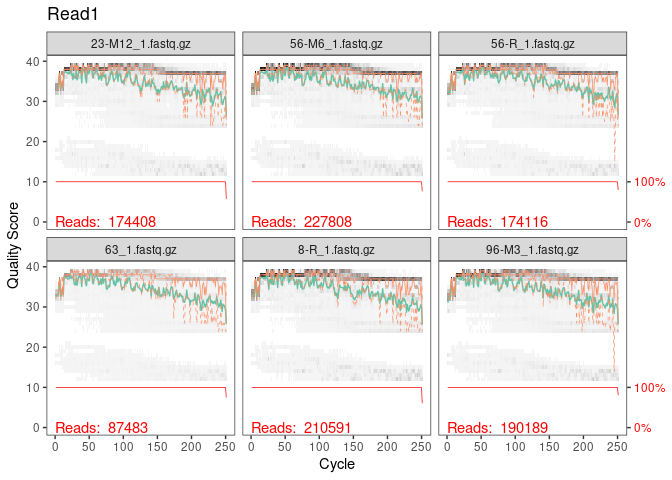

```r
PickSix<-sample(x=length(Read1),replace=F,size=6)
plotQualityProfile(SeqFiles[Read1[PickSix]])+ggtitle("Read1")
```

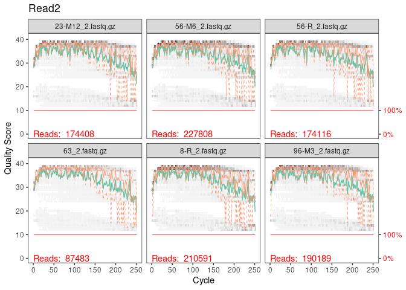

```r
plotQualityProfile(SeqFiles[Read2[PickSix]])+ggtitle("Read2")
```

### Output File

We need a directory to output the filtered reads. This creates one if it doesn’t exist.

```r
FiltPath<-file.path("~/Biol_441/HomeWorks/IndiaTravsOP")
if (dir.exists(FiltPath) ) {
  paste("File Exists, and data will be overwritten!!!")
} else {
  print(paste("No output file, but one will be created."))
  dir.create(FiltPath)
}
```

```
## [1] "File Exists, and data will be overwritten!!!"
```

### Finally we will actually filter the reads!

```r
Read1F<-file.path(FiltPath,basename(SeqFiles[Read1]))
Read2F<-file.path(FiltPath,basename(SeqFiles[Read2]))
MyTime<-proc.time()
FiltResults<-filterAndTrim(fwd = SeqFiles[Read1],
                           filt=Read1F,
                           rev=SeqFiles[Read2],
                           filt.rev=Read2F,
                           truncLen=c(190,175), # Take seq off 3' ends
                           maxEE=c(2,2),
                           multithread=4
                          )
paste("Finish filtering and trimming samples in",
     as.integer((proc.time()-MyTime)[["elapsed"]]),
     "seconds.",
     sep=" ")
```

```
## [1] "Finish filtering and trimming samples in 1983 seconds."
```

### Rerunning quality control

To make sure the reads look quality after trimming we will replot our random 12 reads.

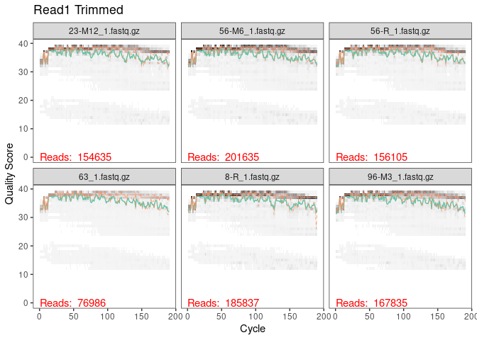

```r
plotQualityProfile(Read1F[PickSix])+ggtitle("Read1 Trimmed")
```

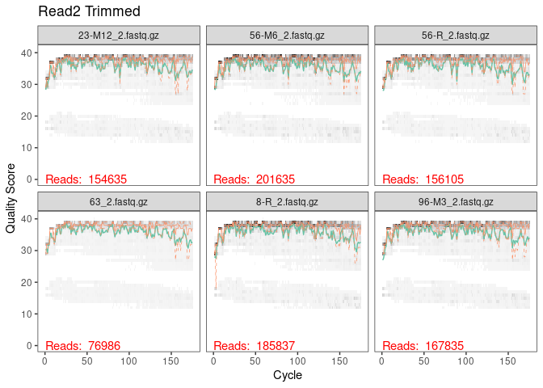

```r
plotQualityProfile(Read2F[PickSix])+ggtitle("Read2 Trimmed")
```

## Learn Errors

The **learnErrors()** function will be run to estimate the frequency of sequencing errors.

```r
MyTime<-proc.time()
Read1Errors<-learnErrors(fls=Read1F,MAX_CONSIST=20,multithread=4)
```

```
## 101180130 total bases in 532527 reads from 3 samples will be used for learning the error rates.
```

```r
Read2Errors<-learnErrors(fls=Read2F,MAX_CONSIST=20,multithread=4)
```

```
## 123501525 total bases in 705723 reads from 4 samples will be used for learning the error rates.
```

```r
paste("Finish learning errors in",
     as.integer((proc.time()-MyTime)[["elapsed"]]),
     "seconds.",
     sep=" ")
```

```
## [1] "Finish learning errors in 15725 seconds."
```

```r
save(Read1Errors,file="/home/palencj/Biol_441/HomeWorks/Read1Errors.RObj")
save(Read2Errors,file="/home/palencj/Biol_441/HomeWorks/Read2Errors.RObj")
```

### Plot the Error Rates

In order to verify that the error rates have been reasonably well estimated, the fit between the observed error rates and (black points), and the fitted error rates (black lines) should be inspected.

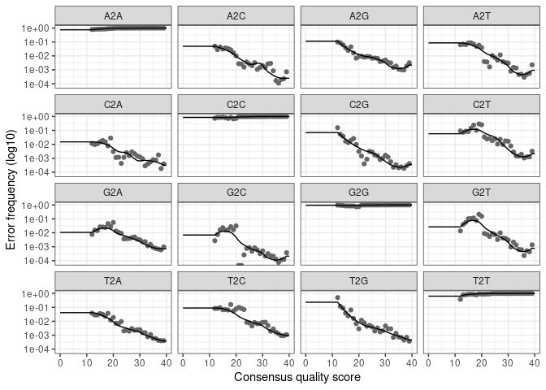

```r
plotErrors(dq=Read1Errors)
```

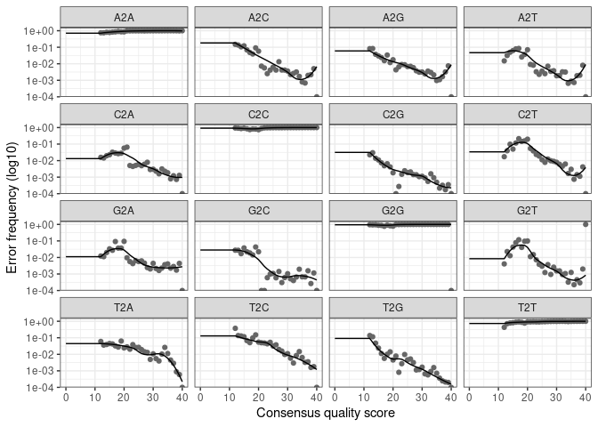

```r
plotErrors(dq=Read2Errors)
```

## Dereplicate the Sequences

The next step in the analysis is to import the filtered sequences into R whilst dereplicating them! During replication, we condense the data down a lot. By collapsing together all the reads that encode the same exact sequence. The exact duplicates will be removed, merging their quality scores.

```r
Read1DeRep<-derepFastq(fls=Read1F,verbose=F)
Read2DeRep<-derepFastq(fls=Read2F,verbose=F)
```

### Rename the Samples

The names of the files need to be cleaned up to use for the column names; they are currently in a character vector with the whole file path, we just want the sample names. + Split the string paths by “/” + Create an object with the sample file’s name’s only + Remove the "_.fastq.gz" from the sample names

```r
SampleNames<-strsplit(Read1F,split="/",fixed=T,perl=F)
Derp<-unlist(SampleNames)
Names2<-Derp[seq(from=5,to=850,by=5)]
Names3<-gsub(Names2,pattern="_1.fastq.gz",replacement="",fixed=T)
names(Read1DeRep)<-Names3
names(Read2DeRep)<-Names3
rm(SampleNames,Derp,Names2)
```

### Find Ribosomal Sequence Variants

The core method of the *dada2* is sample inference; this means figuring out which samples have which variants. Sometimes this step is called “denoising”.

```r
Read1Dada<-dada(Read1DeRep,err=Read1Errors,verbose=0,multithread=4)
Read2Dada<-dada(Read2DeRep,err=Read2Errors,verbose=0,multithread=4)
```

### Merge Reads

The reads now need to be merged. Function **mergePairs()** will merge the denoised forward and reverse reads that have enough overlap.

```r
MergedReads<-mergePairs(dadaF=Read1Dada,
                       derepF=Read1DeRep,
                       dadaR=Read2Dada,
                       derepR=Read2DeRep,
                       verbose=F)
rm(Read1DeRep,Read2DeRep)
```

## Ribosomal Sequence Variants

The RSV table is basically a matrix, where the row names are the samples, and the column names are the sequence variants discovered by *dada2*.

```r
SeqTable<-makeSequenceTable(samples=MergedReads)
dim(SeqTable)
```

```
## [1]    170 142270
```

### Analysis of RSV Lengths

So how long are the RSVs? We are expecting 291 nucleotides. Actually, because of trimming they will probably be a little less. They are not the same length because some prokaryotes have slightly longer or shorter V4 regions.

```r
table(nchar(getSequences(SeqTable)))
```

```
##
##    190    191    192    193    194    195    196    197    198    199    200
##     21      1      3      5      6      6      6      3      1      4      2
##    201    202    203    204    205    206    207    208    209    210    211
##      1      5      2      5     35     11      1      3      1      1      2
##    212    213    215    218    219    220    222    223    224    225    226
##      3      2      5      3     15      8      3      2      3      6      2
##    227    228    229    230    231    232    233    234    236    237    238
##      4      1      4      3      1      7      6      1      6      2      1
##    239    240    242    243    244    245    246    247    248    249    250
##      3      4      1      8      2      2      5     13     68      5      2
##    251    252    253    254    255    256    257    258    260    261    262
##      3      4      6     22      4      3      5      3      3      3      3
##    263    264    265    266    267    268    269    270    271    272    273
##      3      2      5      3      3      2      4      3      6      2      4
```

[output cut: 16 more lines]

This selects the RSVs at the appropriate lengths we want to analyze, 290-293.

```r
SeqTable<-SeqTable[,nchar(colnames(SeqTable)) %in% seq(290,293)] # selects only RSVs from 290 to 293
```

## Remove the Chimeras

Chimeras are sequences introduced by PCR that are not part of the sequence we desire and must be removed. (stnc= seq table with no chimeras)

```r
stnc<-removeBimeraDenovo(SeqTable,method="consensus",multithread=4,verbose=F)
dim(stnc)
```

```
## [1]   170 22072
```

```r
save(stnc,file="/home/palencj/Biol_441/HomeWorks/India_stnc.RObj")
```

The number of samples has been conserved, however there are a great many less RSVs.

## Summary of Read Processing

We will make a kable using *knitr* and *kableExtra* summarizing our reads from step to step. (3) (4)

```r
getN<-function(x) sum(getUniques(x))
track<-cbind(FiltResults,
             sapply(X=Read1Dada,FUN=getN),
             sapply(X=Read2Dada,FUN=getN),
             sapply(X=MergedReads,FUN=getN),
             rowSums(stnc))
colnames(track)<-c("Input","Filtered","DenoisedF","DenoisedR","Merged","Non-chimeric")
rownames(track)<-Names3
# PDF: xtable, HTML: kable
kable_styling(kable_input=kable(track),
              bootstrap_options=c("striped","hover","condensed"),
              full_width=F)
```

|  | Input | Filtered | DenoisedF | DenoisedR | Merged | Non-chimeric |
| --- | --- | --- | --- | --- | --- | --- |
| 100 | 300322 | 273518 | 271605 | 269383 | 253897 | 167038 |
| 100-M12 | 146409 | 132989 | 131564 | 130573 | 120689 | 84145 |
| 100-M3 | 140161 | 126020 | 124822 | 123974 | 114901 | 78241 |
| 100-M6 | 191516 | 173196 | 171622 | 170321 | 158198 | 112527 |
| 100-R | 320452 | 287320 | 285025 | 283157 | 264925 | 169254 |
| 14 | 186365 | 166585 | 163966 | 161136 | 147938 | 102428 |
| 14-M3 | 135269 | 118819 | 118314 | 117342 | 110597 | 72243 |
| 14-R | 186051 | 167308 | 166209 | 164072 | 153555 | 105534 |
| 18 | 140228 | 125912 | 124831 | 123305 | 113749 | 74010 |
| 18-M12 | 131923 | 116987 | 115923 | 114254 | 103352 | 67964 |
| 18-M3 | 198581 | 175183 | 173922 | 171821 | 157498 | 103959 |
| 18-M6 | 161215 | 142993 | 141643 | 139801 | 125360 | 84530 |
| 18-R | 120097 | 107101 | 106124 | 104020 | 96243 | 69715 |
| 19 | 189619 | 162827 | 162043 | 160741 | 152836 | 113740 |
| 19-M12 | 157809 | 140508 | 139612 | 137657 | 129621 | 94030 |
| 19-M3 | 161256 | 142917 | 142026 | 140807 | 133177 | 98865 |
| 19-M6 | 150296 | 131935 | 130576 | 128671 | 118157 | 82428 |
| 19-R | 173461 | 154559 | 152991 | 151720 | 140574 | 94903 |
| 23 | 217985 | 194475 | 192385 | 189665 | 172769 | 114049 |
| 23-M12 | 174408 | 154635 | 153903 | 152545 | 145178 | 100785 |
| 23-M3 | 199892 | 176609 | 175262 | 173370 | 163010 | 117874 |
| 23-M6 | 134616 | 119054 | 118300 | 117645 | 112060 | 80757 |
| 23-R | 213288 | 188766 | 187687 | 185257 | 175739 | 129950 |
| 26 | 138236 | 122786 | 121878 | 120515 | 113853 | 87236 |
| 26-M12 | 114209 | 100418 | 99319 | 97798 | 88421 | 66145 |
| 26-M3 | 227050 | 203498 | 202030 | 199923 | 189158 | 137730 |
| 26-M6 | 130676 | 114028 | 112761 | 110676 | 100014 | 73990 |
| 26-R | 157775 | 139919 | 138401 | 136624 | 126237 | 89857 |
| 29 | 65471 | 57112 | 56242 | 54981 | 48346 | 32903 |
| 29-M12 | 175222 | 157500 | 156590 | 155486 | 146693 | 92109 |

[output cut: 140 more lines]

```r
rm(FiltResults,Read1Dada,Read2Dada,track)
```

## Produce Taxonomy Table

Here the taxonomy will be assigned to each of the RSV’s discovered in the samples. We are going to use training sets from SilvaDB and *dada2* to assign the taxonomy. (5)

We will also assign the species for the sequences that can be discerned to that level.

```r
Taxa<-assignTaxonomy(seqs=stnc,refFasta="/opt/SilvaDB/v132/silva_nr_v132_train_set.fa.gz",multithread=3)

taxa<-addSpecies(taxtab=Taxa,
                 refFasta="/opt/SilvaDB/v132/silva_species_assignment_v132.fa.gz")
save(taxa,file="/home/palencj/Biol_441/HomeWorks/IT_Taxa_W_Species.RObj")
```

This concludes the *dada2* portion of the workflow.

## Import Phenotype Table

The phenotable contains all the independent variables that are pertinent to the experiment, such as the time point relative to their trip, if the traveler had been to SE Asia, if they took antibiotics, if they had abdominal pain, and if their gut was colonized. The table was made in excel and imported as a CSV file. We need to set the rownames as the values in the first column, then remove that column.

```r
PhenoCsv<-read.csv("/home/palencj/Biol_441/HomeWorks/India Phenotype Table.csv")
rownames(PhenoCsv)<-PhenoCsv[,1]
PhenoCsv<-PhenoCsv[,-1]
```

# Analysis with Phyloseq

We now turn to the *phyloseq* package to perform further analysis on our microbial community data. (6)

This will construct a phyloseq object with the *dada2* STNC, Taxa table and the Phenotable.

```r
PS<-phyloseq(otu_table(object=stnc,taxa_are_rows=F),
             sample_data(object=PhenoCsv),
             tax_table(object=taxa))
save(PS,file="/home/palencj/Biol_441/HomeWorks/India_PS.RObj")
rm(stnc,PhenoCsv,taxa)
```

```r
load(file="/home/palencj/Biol_441/HomeWorks/India_PS.RObj")
```

## Examine Mocks

Now we will pull the mocks, HV1 and HV2, out of the sample and list the genus’s found and their frequencies.

```r
Mock<-subset_samples(PS, TravelerID %in% c("HV1","HV2"))
MockNotZero<-prune_taxa(x=Mock,taxa_sums(Mock)>0)

kable(table(tax_table(MockNotZero)[,"Genus"]),col.names=c("Genus","Frequency"))
```

| Genus | Frequency |
| --- | --- |
| Acetanaerobacterium | 1 |
| Agathobacter | 52 |
| Akkermansia | 30 |
| Alistipes | 162 |
| Alloprevotella | 18 |
| Anaerofilum | 12 |
| Anaeroplasma | 18 |
| Anaerostipes | 15 |
| Angelakisella | 3 |
| Bacteroides | 305 |
| Barnesiella | 33 |
| Bifidobacterium | 51 |
| Bilophila | 34 |
| Blautia | 91 |
| Butyricicoccus | 41 |
| Butyricimonas | 6 |
| CAG-56 | 7 |
| Campylobacter | 2 |
| Candidatus_Soleaferrea | 1 |
| Caproiciproducens | 25 |
| Catabacter | 2 |
| Catenibacterium | 21 |
| Christensenellaceae_R-7_group | 115 |
| Cloacibacillus | 2 |
| Clostridium_sensu_stricto_1 | 11 |
| Collinsella | 22 |
| Coprobacter | 13 |
| Coprococcus_1 | 4 |
| Coprococcus_2 | 22 |
| Coprococcus_3 | 26 |

[output cut: 88 more lines]

These are the details of the Mock PS object:

```r
Mock
```

```
## phyloseq-class experiment-level object
## otu_table()   OTU Table:         [ 22072 taxa and 8 samples ]
## sample_data() Sample Data:       [ 8 samples by 6 sample variables ]
## tax_table()   Taxonomy Table:    [ 22072 taxa by 7 taxonomic ranks ]
```

These are the details of the Mock that had frequencies higher than 0.

```r
MockNotZero
```

```
## phyloseq-class experiment-level object
## otu_table()   OTU Table:         [ 3523 taxa and 8 samples ]
## sample_data() Sample Data:       [ 8 samples by 6 sample variables ]
## tax_table()   Taxonomy Table:    [ 3523 taxa by 7 taxonomic ranks ]
```

There was a big drop in the number of taxa but there’s still 8 samples and 7 taxonomy ranks.

The mocks look good, so they will be removed from the phyloseq object.

```r
PS<-subset_samples(PS, TravelerID != "HV1"& TravelerID != "HV2")
PS
```

```
## phyloseq-class experiment-level object
## otu_table()   OTU Table:         [ 22072 taxa and 162 samples ]
## sample_data() Sample Data:       [ 162 samples by 6 sample variables ]
## tax_table()   Taxonomy Table:    [ 22072 taxa by 7 taxonomic ranks ]
```

There are 8 less samples but the number of taxa is the same.

## Investigate Read Depth

The *ggplot2* package was used to create the histograms showing the breakdown of sequencing depth. (7)

This will model the sequencing depth of the non-chimeric reads. It should have a bell shape.

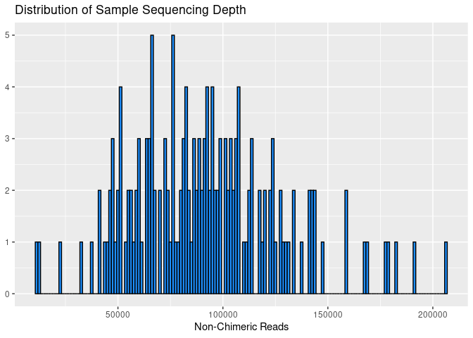

```r
sample_sum_df<-data.frame(Sums=sample_sums(PS))
ggplot(data=sample_sum_df, aes(x=Sums)) +
  geom_histogram(color="black",fill="dodger blue",binwidth=1250) +
  ggtitle("Distribution of Sample Sequencing Depth") +
  xlab("Non-Chimeric Reads") +
  theme(axis.title.y=element_blank())
```

This looks good but to be sure, any sequences with less than 1500 nonchimeric reads will be removed.

```r
PS<-prune_samples(x=PS,samples=(sample_sums(PS)>1500))
PS
```

```
## phyloseq-class experiment-level object
## otu_table()   OTU Table:         [ 22072 taxa and 162 samples ]
## sample_data() Sample Data:       [ 162 samples by 6 sample variables ]
## tax_table()   Taxonomy Table:    [ 22072 taxa by 7 taxonomic ranks ]
```

## Display the Data

### General Diversity

It will help to visualize the data.

Here is a pie chart of all the phyla. The phylum that contains the Enterobacteriaceae is Proteobacteria.

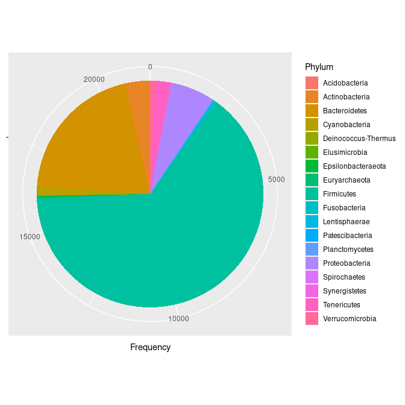

```r
MyPhyla<-as.data.frame(table(tax_table(PS)[,"Phylum"]))
colnames(MyPhyla)<-c("Phylum","Frequency")
BP<-ggplot(data=MyPhyla, aes(x="",y=Frequency,fill=Phylum)) +
  geom_bar(width=1,stat="identity")
MyPie<-BP+coord_polar("y",start=0)+theme(axis.title.y=element_blank())
MyPie
```

This is a pie chart of all the orders found in the PS object. Enterobacteriales is the order of concern.

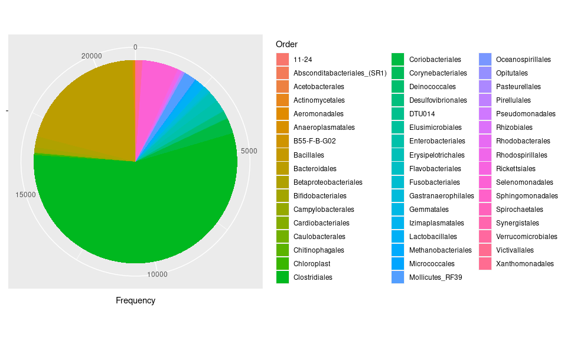

```r
MyOrder<-as.data.frame(table(tax_table(PS)[,"Order"]))
colnames(MyOrder)<-c("Order","Frequency")
BP<-ggplot(data=MyOrder, aes(x="",y=Frequency,fill=Order)) +
  geom_bar(width=0.5,stat="identity")
MyPie<-BP+coord_polar("y",start=0)+theme(axis.title.y=element_blank())
MyPie
```

With so much diversity in the microbiomes, these pie charts are not super useful, especially as the taxonomic ranks get more specific.

Here is a graph showing the overall phyla diversity based on the antibiotic status.

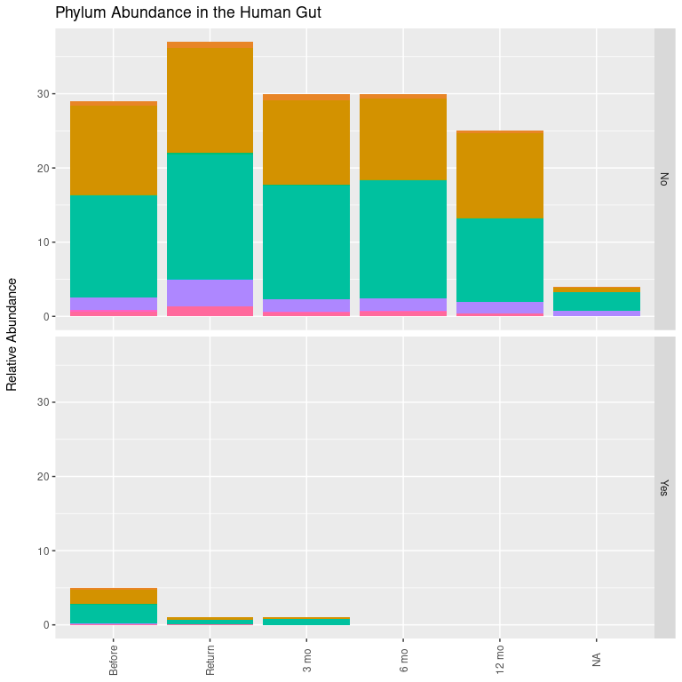

```r
Stack<-tax_glom(physeq=PS,taxrank="Phylum")
Stack<-transform_sample_counts(physeq=Stack,fun=function(x) {x/sum(x)})
Stack<-arrange(.data=psmelt(physeq=Stack),Phylum)
Stack$Timepoint <- factor(Stack$Timepoint,
                                        levels=c("Before","Return","3 mo","6 mo","12 mo"))
ggplot(Stack, aes(x=Timepoint,y=Abundance,fill=Phylum)) +
  facet_grid(Took.Abs~.) +
  geom_bar(stat="identity") +
  theme(axis.title.x=element_blank(),
        axis.text.x=element_text(angle=90,vjust=0.5),
        legend.position="none") +
  ylab("Relative Abundance \n") +
  ggtitle("Phylum Abundance in the Human Gut")
```

## Enterobacteriaceae

These are the genus names of the Enterobacteriaceae

```r
# Pull out the samples with the family name Enterobacteriaceae
genusS<-subset_taxa(PS, Family %in% "Enterobacteriaceae")
kable(table(tax_table(genusS)[,"Genus"]),col.names=c("Genus","Frequency"))
```

| Genus | Frequency |
| --- | --- |
| ATCC-39006 | 24 |
| Atlantibacter | 4 |
| Cosenzaea | 5 |
| Escherichia/Shigella | 80 |
| Hafnia-Obesumbacterium | 7 |
| Leminorella | 1 |
| Morganella | 11 |
| Phaseolibacter | 1 |
| Pluralibacter | 1 |
| Proteus | 4 |
| Providencia | 2 |
| Pseudocitrobacter | 47 |
| Rosenbergiella | 2 |
| Shimwellia | 1 |
| Tatumella | 1 |

Here is a stacked barplot to show the diversity, made with the genus’s from the Enterobacteriaceae.

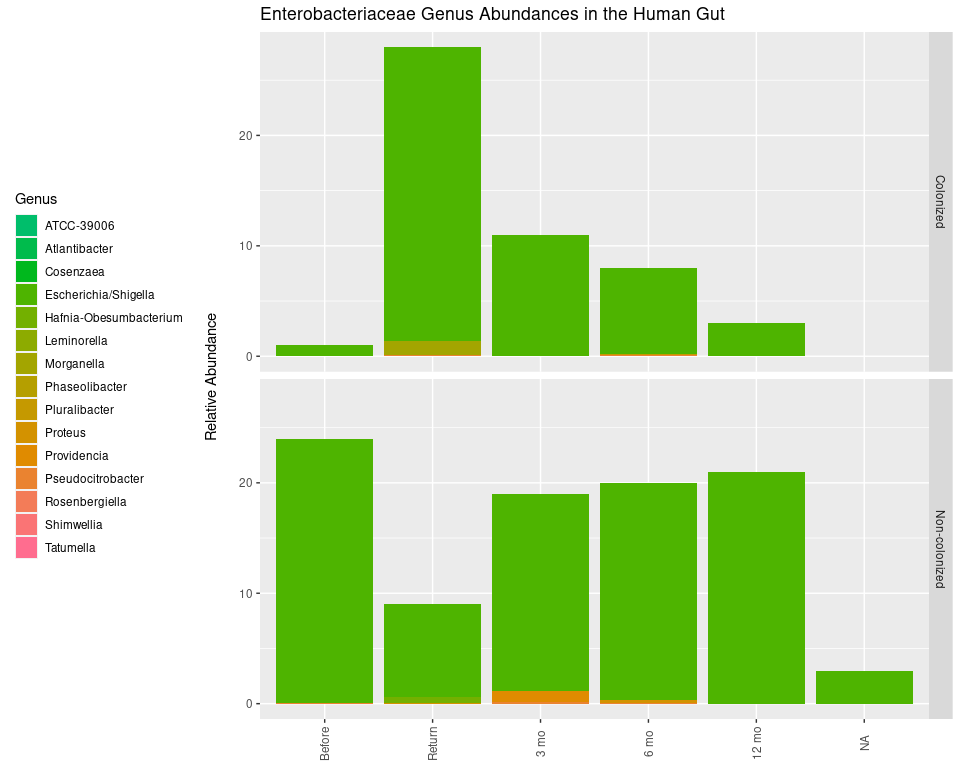

```r
BetterColors<- function(ncolors) {
  hues<-seq(from=1,to=162,length=ncolors+1)
  hcl(h=hues,l=65,c=100)[1:ncolors]
}
Stack<-tax_glom(physeq=genusS,taxrank="Genus")
Stack<-transform_sample_counts(physeq=Stack,fun=function(x) {x/sum(x)} )
Stack<-arrange(.data=psmelt(physeq=Stack),Genus)
# Refactor axis
Stack$Timepoint <- factor(Stack$Timepoint,
                                        levels=c("Before","Return","3 mo","6 mo","12 mo"))
ggplot(Stack, aes(x=Timepoint,y=Abundance,fill=Genus)) +
  facet_grid(Colonized~.) +
  geom_bar(stat="identity") +
  scale_fill_manual(values=rev(BetterColors(ncolors=15))) +
  theme(axis.title.x=element_blank(),
        axis.text.x=element_text(angle=90,vjust=0.5),
        legend.position="left") +
  ylab("Relative Abundance \n") +
  ggtitle("Enterobacteriaceae Genus Abundances in the Human Gut")
```

There is a spike in travelers classified as colonized when they returned.There appears to be more diversity in the non-colonized group.

```r
rm(genusS)
```

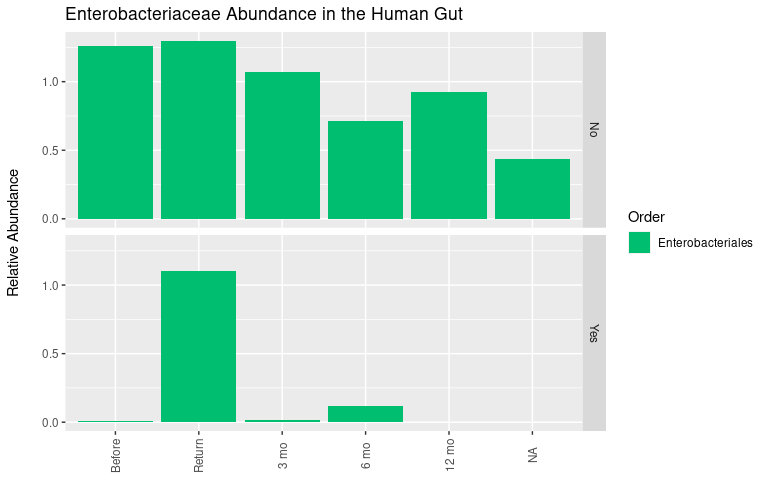

```r
Stack<-tax_glom(physeq=PS,taxrank="Family")
Stack<-transform_sample_counts(physeq=Stack,fun=function(x) {x/sum(x)} )
Stack<-arrange(.data=psmelt(physeq=Stack),Family)
Enterobacteriaceae<-subset(Stack,Family=="Enterobacteriaceae")
# Refactor axis
Enterobacteriaceae$Timepoint <- factor(Enterobacteriaceae$Timepoint,
                                        levels=c("Before","Return","3 mo","6 mo","12 mo"))
ggplot(Enterobacteriaceae, aes(x=Timepoint,y=Abundance,fill=Order)) +
  facet_grid(AbdSymptoms~.) +
  geom_bar(stat="identity") +
  scale_fill_manual(values=rev(BetterColors(ncolors=18))) +
  theme(axis.title.x=element_blank(),
        axis.text.x=element_text(angle=90,vjust=0.5),
        legend.position="right") +
  ylab("Relative Abundance \n") +
  ggtitle("Enterobacteriaceae Abundance in the Human Gut")
```

```r
rm(Stack,MyPhyla)
```

## Proteobacteria

This time **tax_glom()** will be used to subset at the phyla level.

```r
phylaPS<-tax_glom(physeq=PS,taxrank="Phylum")
phylaPS<-transform_sample_counts(physeq=phylaPS,fun=function(x) {x/sum(x)} )
phylaPS<-arrange(.data=psmelt(physeq=phylaPS),Phylum)
# Refactor axis
phylaPS$Timepoint <- factor(phylaPS$Timepoint,
                                        levels=c("Before","Return","3 mo","6 mo","12 mo"))
```

This shows the phyla diversity from the whole microbiome, split into categories based off if the individual’s guts were colonized.

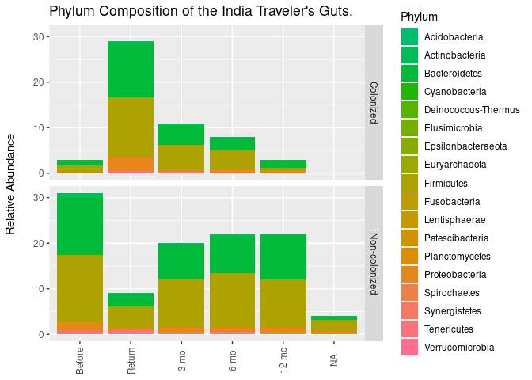

```r
ggplot(phylaPS, aes(x=Timepoint,y=Abundance,fill=Phylum)) +
  facet_grid(Colonized~.) +
  geom_bar(stat="identity") +
  scale_fill_manual(values=rev(BetterColors(ncolors=18))) +
  theme(axis.title.x=element_blank(),
        axis.text.x=element_text(angle=90,vjust=0.5)) +
        #axis.text.y.left = element_blank()) +
  ylab("Relative Abundance \n") +
  ggtitle("Phylum Composition of the India Traveler's Guts.")
```

There seem to be a difference here at the before and return timepoints. In the non-colonized group, the phyla abundance decreases while the colonized group increases.

Another variable could be tested. Here, the graph will show the abundance of the microbiomes at the phylum level for travelers who traveled to southeast Asia.

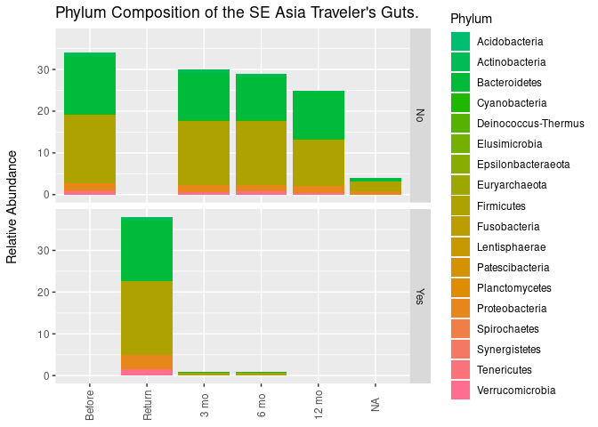

```r
ggplot(phylaPS, aes(x=Timepoint,y=Abundance,fill=Phylum)) +
  facet_grid(SE.Asia~.) +
  geom_bar(stat="identity") +
  scale_fill_manual(values=rev(BetterColors(ncolors=18))) +
  theme(axis.title.x=element_blank(),
        axis.text.x=element_text(angle=90,vjust=0.5)) +
        #axis.text.y.left = element_blank()) +
  ylab("Relative Abundance \n") +
  ggtitle("Phylum Composition of the SE Asia Traveler's Guts.")
```

There also appears to be something here. At the return timepoint there is a large increase in abundance for the travelers who went to southeast Asia.

## Summarize Abundances

Now, this plot shows the mean and standard deviations of Enterobacteriaceae abundances.

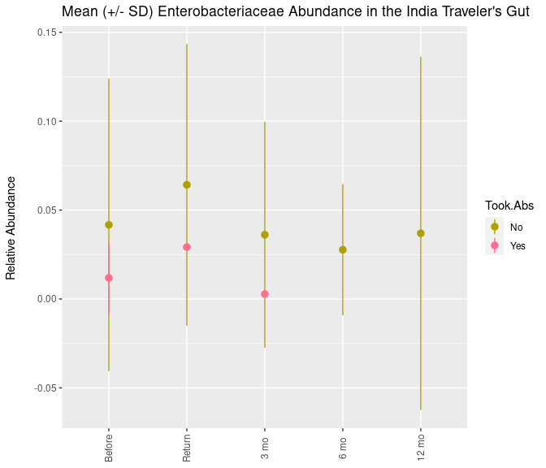

```r
Mean<-aggregate(Abundance~Took.Abs*Timepoint,data=Enterobacteriaceae,FUN="mean")
SD<-aggregate(Abundance~Took.Abs*Timepoint,data=Enterobacteriaceae,FUN="sd")
MeanSD<-merge(x=Mean,y=SD,by=c("Took.Abs","Timepoint"))
colnames(MeanSD)<-c("Took.Abs","Timepoint","Mean","Stdev")
# Plot
ggplot(MeanSD, aes(x=Timepoint,y=Mean,ymin=Mean-Stdev,ymax=Mean+Stdev)) +
  geom_pointrange(mapping=aes(colour=Took.Abs)) +
  scale_colour_manual(values=rev(BetterColors(ncolors=2))) +
  theme(axis.title.x=element_blank(),
        axis.text.x=element_text(angle=90,vjust=0.5)) +
  ylab("Relative Abundance \n") +
  ggtitle("Mean (+/- SD) Enterobacteriaceae Abundance in the India Traveler's Gut")
```

The mean abundance for antibiotic takers is less on the graph, but it should be noted that there are far fewer samples under the antibiotic group then the non-antibiotic!

Let’s see what it looks like for colonized vs non-colonized individuals.

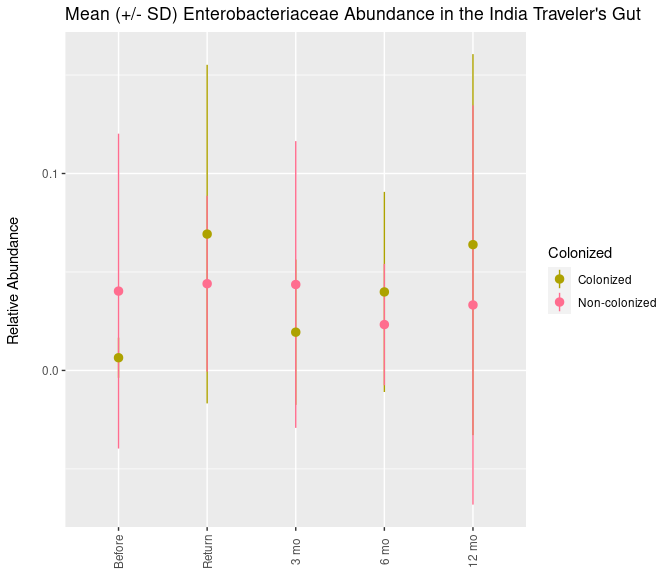

```r
ColMean<-aggregate(Abundance~Colonized*Timepoint,data=Enterobacteriaceae,FUN="mean")
ColSD<-aggregate(Abundance~Colonized*Timepoint,data=Enterobacteriaceae,FUN="sd")
ColMeanSD<-merge(x=ColMean,y=ColSD,by=c("Colonized","Timepoint"))
colnames(ColMeanSD)<-c("Colonized","Timepoint","Mean","Stdev")
# Plot
ggplot(ColMeanSD, aes(x=Timepoint,y=Mean,ymin=Mean-Stdev,ymax=Mean+Stdev)) +
  geom_pointrange(mapping=aes(colour=Colonized)) +
  scale_colour_manual(values=rev(BetterColors(ncolors=2))) +
  theme(axis.title.x=element_blank(),
        axis.text.x=element_text(angle=90,vjust=0.5)) +
  ylab("Relative Abundance \n") +
  ggtitle("Mean (+/- SD) Enterobacteriaceae Abundance in the India Traveler's Gut")
```

```r
rm(BetterColors)
```

The mean of colonized individuals increases much more than the non-colonized group does upon returning from India.

```r
rm(Mean,SD,MeanSD,ColMean,ColSD,ColMeanSD,Mock,MockNotZero,MyPie)
```

# Test for Significance

Test whether there is a difference between the group that took antibiotics and the one that did not, using the Mann-Whitney test. The null hypothesis: There is no difference in median abundance of Enterobacteriaceae from individuals that took antibiotics and those that did not. $\alpha=0.02$

```r
wilcox.test(formula=Abundance~Took.Abs,data=Enterobacteriaceae,paired=F,exact=F)
```

```
##
##  Wilcoxon rank sum test with continuity correction
##
## data:  Abundance by Took.Abs
## W = 691.5, p-value = 0.2212
## alternative hypothesis: true location shift is not equal to 0
```

This p value is above the threshold, so the null is accepted. There is no difference between the two groups.

The relationship between abundance and the colonization status should also be tested. The null hypothesis: There is no difference in median abundance of Enterobacteriaceae from individuals that were colonized and those that did not. $\alpha=0.02$

```r
wilcox.test(formula=Abundance~Colonized,data=Enterobacteriaceae,paired=F,exact=F)
```

```
##
##  Wilcoxon rank sum test with continuity correction
##
## data:  Abundance by Colonized
## W = 3523.5, p-value = 0.03102
## alternative hypothesis: true location shift is not equal to 0
```

This looks better but not quite below the $p<0.02$ threshold. Another variable to try is the southeast travelers.

```r
wilcox.test(formula=Abundance~SE.Asia,data=Enterobacteriaceae,paired=F,exact=F)
```

```
##
##  Wilcoxon rank sum test with continuity correction
##
## data:  Abundance by SE.Asia
## W = 1285, p-value = 7.311e-06
## alternative hypothesis: true location shift is not equal to 0
```

## Permanova

Tested here is the RSV abundances and the colonized status. $H_o$ : There is no abudnance difference between idividuals who were classified as colonized and non-colonized.

```r
rm(Enterobacteriaceae)
PS_Comp<-microbiome::transform(x=PS,transform="compositional")
RSV_Abundances<-abundances(PS_Comp)
Phenos<-meta(PS_Comp)
Permanova<-adonis(t(RSV_Abundances)~Colonized,data=Phenos,permutations=999,method="bray")
Permanova
```

```
##
## Call:
## adonis(formula = t(RSV_Abundances) ~ Colonized, data = Phenos,      permutations = 999, method = "bray")
##
## Permutation: free
## Number of permutations: 999
##
## Terms added sequentially (first to last)
##
##            Df SumsOfSqs MeanSqs F.Model      R2 Pr(>F)
## Colonized   1     0.421 0.42138  1.2457 0.00773  0.148
## Residuals 160    54.124 0.33827         0.99227
## Total     161    54.545                 1.00000
```

This p value is not acceptable. The null hypothesis is accepted. If it was rejected this is what would be used next.

```r
PS.Bray<-distance(physeq=PS_Comp,method="bray")
PS.Df<-data.frame(sample_data(PS))
permutest(betadisper(d=PS.Bray,with(PS.Df,Colonized)))
```

```
##
## Permutation test for homogeneity of multivariate dispersions
## Permutation: free
## Number of permutations: 999
##
## Response: Distances
##            Df  Sum Sq   Mean Sq      F N.Perm Pr(>F)
## Groups      1 0.00563 0.0056299 1.3849    999  0.239
## Residuals 160 0.65045 0.0040653
```

This would also be accepted. There is no meaningful difference in the RSVs from the two groups.

This test is the same permanova but using the southeast Asia status for testing.

```r
PS_Comp<-microbiome::transform(x=PS,transform="compositional")
RSV_Abundances<-abundances(PS_Comp)
Phenos<-meta(PS_Comp)
Permanova<-adonis(t(RSV_Abundances)~SE.Asia,data=Phenos,permutations=999,method="bray")
Permanova
```

```
##
## Call:
## adonis(formula = t(RSV_Abundances) ~ SE.Asia, data = Phenos,      permutations = 999, method = "bray")
##
## Permutation: free
## Number of permutations: 999
##
## Terms added sequentially (first to last)
##
##            Df SumsOfSqs MeanSqs F.Model      R2 Pr(>F)
## SE.Asia     1     0.420 0.41955  1.2402 0.00769  0.145
## Residuals 160    54.126 0.33828         0.99231
## Total     161    54.545                 1.00000
```

With this p value, the null will be accepted. If it could be rejected a **permutest()** would be used next to further varify that there was a difference in the southeast Asia groups.

```r
PS.Bray<-distance(physeq=PS_Comp,method="bray")
PS.Df<-data.frame(sample_data(PS))
permutest(betadisper(d=PS.Bray,with(PS.Df,SE.Asia)))
```

```
##
## Permutation test for homogeneity of multivariate dispersions
## Permutation: free
## Number of permutations: 999
##
## Response: Distances
##            Df  Sum Sq   Mean Sq      F N.Perm Pr(>F)
## Groups      1 0.00091 0.0009066 0.2275    999  0.644
## Residuals 160 0.63757 0.0039848
```

This is a third multivariate test on the traveler’s abdominal pain status.

```r
PS_Comp<-microbiome::transform(x=PS,transform="compositional")
RSV_Abundances<-abundances(PS_Comp)
Phenos<-meta(PS_Comp)
Permanova<-adonis(t(RSV_Abundances)~AbdSymptoms,data=Phenos,permutations=999,method="bray")
Permanova
```

```
##
## Call:
## adonis(formula = t(RSV_Abundances) ~ AbdSymptoms, data = Phenos,      permutations = 999, method = "bray")
##
## Permutation: free
## Number of permutations: 999
##
## Terms added sequentially (first to last)
##
##              Df SumsOfSqs MeanSqs F.Model      R2 Pr(>F)
## AbdSymptoms   1     0.312 0.31236 0.92155 0.00573  0.546
## Residuals   160    54.233 0.33895         0.99427
## Total       161    54.545                 1.00000
```

The null hypothesis here is accepted, there is no difference. If there was **permutest()** could be used to further check if there was a meaningful difference between the two groups.

```r
PS.Bray<-distance(physeq=PS_Comp,method="bray")
PS.Df<-data.frame(sample_data(PS))
permutest(betadisper(d=PS.Bray,with(PS.Df,AbdSymptoms)))
```

```
##
## Permutation test for homogeneity of multivariate dispersions
## Permutation: free
## Number of permutations: 999
##
## Response: Distances
##            Df  Sum Sq   Mean Sq      F N.Perm Pr(>F)
## Groups      1 0.00164 0.0016396 0.4116    999  0.504
## Residuals 160 0.63737 0.0039836
```

This further shows that there is no difference in the abdominal symptom groups

## Investigate Alpha Diversity

The next step would be to test the $\alpha$ diversity.

Now we will investigate alpha diversity. Nathan made a function to help with that:

```r
Func <- function (physeq, x = "samples", color = NULL, shape = NULL,
          title = NULL, scales = "free_y", nrow = 1, shsi = NULL, measures = NULL,
          sortby = NULL)
{
  erDF = estimate_richness(physeq, split = TRUE, measures = measures)
  measures = colnames(erDF)
  ses = colnames(erDF)[grep("^se\\.", colnames(erDF))]
  measures = measures[!measures %in% ses]
  if (!is.null(sample_data(physeq, errorIfNULL = FALSE))) {
    DF <- data.frame(erDF, sample_data(physeq))
  }
  else {
    DF <- data.frame(erDF)
  }
  if (!"samples" %in% colnames(DF)) {
    DF$samples <- sample_names(physeq)
  }
  if (!is.null(x)) {
    if (x %in% c("sample", "samples", "sample_names", "sample.names")) {
      x <- "samples"
    }
  }
  else {
    x <- "samples"
  }
  mdf = reshape2::melt(DF, measure.vars = measures)
  mdf$se <- NA_integer_
  if (length(ses) > 0) {
    selabs = ses
    names(selabs) <- substr(selabs, 4, 100)
    substr(names(selabs), 1, 1) <- toupper(substr(names(selabs),
                                                  1, 1))
    mdf$wse <- sapply(as.character(mdf$variable), function(i,
                                                           selabs) {
      selabs[i]
    }, selabs)
    for (i in 1:nrow(mdf)) {
      if (!is.na(mdf[i, "wse"])) {
        mdf[i, "se"] <- mdf[i, (mdf[i, "wse"])]
      }
    }
    mdf <- mdf[, -which(colnames(mdf) %in% c(selabs, "wse"))]
  }
  if (!is.null(measures)) {
    if (any(measures %in% as.character(mdf$variable))) {
      mdf <- mdf[as.character(mdf$variable) %in% measures,
      ]
    }
    else {
      warning("Argument to `measures` not supported. All alpha-diversity measures (should be) included in plot.")
    }
  }
  if (!is.null(shsi)) {
    warning("shsi no longer supported option in plot_richness. Please use `measures` instead")
  }
  if (!is.null(sortby)) {
    if (!all(sortby %in% levels(mdf$variable))) {
      warning("`sortby` argument not among `measures`. Ignored.")
    }
    if (!is.discrete(mdf[, x])) {
      warning("`sortby` argument provided, but `x` not a discrete variable. `sortby` is ignored.")
    }
    if (all(sortby %in% levels(mdf$variable)) & is.discrete(mdf[,
                                                                x])) {
      wh.sortby = which(mdf$variable %in% sortby)
      mdf[, x] <- factor(mdf[, x], levels = names(sort(tapply(X = mdf[wh.sortby,
                                                                      "value"], INDEX = mdf[wh.sortby, x], mean, na.rm = TRUE,
                                                              simplify = TRUE))))
    }
  }
  richness_map = aes_string(x = x, y = "value", colour = color,
                            shape = shape)
  p = ggplot(mdf, richness_map) + geom_point(na.rm = TRUE, position = position_dodge(width = 0.5)) # add this section to separate the points horizontally.
  # Comment or remove this to delete error bars

  p = p + theme(axis.text.x = element_text(angle = -90, vjust = 0.5,
                                           hjust = 0))
  p = p + ylab("Alpha Diversity Measure")
  p = p + facet_wrap(~variable, nrow = nrow, scales = scales)
  if (!is.null(title)) {
    p <- p + ggtitle(title)
  }
  return(p)
}
```

Here the $\alpha$ diversity will be plotted by the Chao1 and InvSimpson methods. The graph is showing the $\alpha$ diversity for the colonized and non-colonized individuals and their antibiotic usage. The hypothesis here tests if there is a difference in bacterial diversity within the samples based on if they took antibiotics

```r
AlphaDiv<-plot_richness(physeq=PS,
                        x="Took.Abs",
                        measures=c("Chao1","InvSimpson"),
                        color="Colonized")
# Refactor the X-axis "
MyOrder<-dput(as.character(sort(as.numeric(levels(AlphaDiv[["data"]][["Timepoint"]])))))
```

```
## character(0)
```

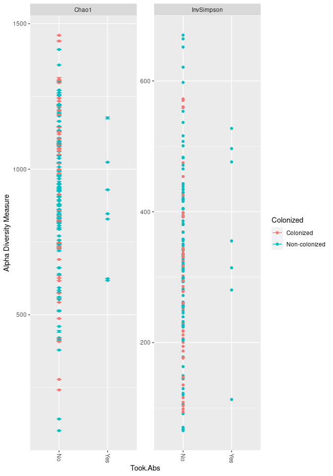

```r
AlphaDiv[["data"]][["Timepoint"]]<-factor(AlphaDiv[["data"]][["Timepoint"]],
                                     levels=MyOrder)
AlphaDiv
```

```r
rm(PS_Comp,PS.DF,Phenos,Permanova)
```